# Annual Report on Vital Signs monitoring of distribution and abundance of Bald Eagles in Wrangell-St. Elias National Park and Preserve, 2023

Kyle Cutting<sup>1</sup> and Scott Miller<sup>2</sup>

<sup>1</sup>National Park Service, Wrangell St. Elias National Park and Preserve, 8 Richardson Hwy Mile 106, Copper Center, AK 99573

<sup>2</sup>National Park Service, Arctic Inventory and Monitoring Network,240 W. 5th Ave Anchorage, Alaska 99501

May 14, 2024

U.S. Department of the Interior  
National Park Service  
Natural Resource Stewardship and Science  
Fort Collins, Colorado

# Introduction

The Copper River in Wrangell-St. Elias National Park and Preserve (WRST), Alaska, contains a high density of nesting Bald Eagles *(Haliaeetus leucocephalus)* and the National Park Service has identified Bald Eagles as a focal fauna species to monitor. Bald Eagles in WRST are a high profile species that are dependent upon many resources along the Copper River and nest at the northern edge of the their range. Bald Eagles are top-trophic level predators and they often respond quickly to changes in their environment by changing their breeding activities. In 2023 we conducted an aerial bald eagle productivity survey in and around the park. Nest occupancy surveys were flown from May 15, 2023 to May 18, 2023 , followed by productivity surveys from July 29, 2013 to July 29, 2023 . We observed 289 nests, of which 103 were occupied (36%). Productivity surveys revealed that 67 occupied nests producing young (69% of occupied nests). Successful nests resulted in 101 young, an average of 1.51 young per successful nest.

Key Words: Wrangell-St. Elias National Park and Preserve, Bald Eagle, *Haliaeetus leucocephalus*, Population dynamics, monitoring, 2023

# Objectives

The objectives of the monitoring efforts are to:

- Document the annual changes in occupancy of bald eagles,
- Document the annual changes in productivity of bald eagle nests, and
- Document any changes in distribution of bald eagle nests.

# Methods

The 2023 bald eagle survey followed the same methods (Putera and Miller, 2018) that have been used since 1989. Five survey areas were defined along the Copper River and its major tributaries (Figure 1):

1.) The Upper Copper River (UCR, 80km) extends from Copper and Tanada lakes to the confluence of the Chistochina River. White spruce (Picea glauca) is the predominant tree species, with balsam poplar (Populus balsamifera) common on the lower stretches. The Middle Copper River (MCR, 179km) extends from the Chistochina River south to the confluence of the Chitina River.

2.) The Middle Copper River (MCR) contains a mixture of both white spruce and balsam poplar, with poplar being slightly more common. The Copper River begins to braid along the MCR.

2.) The Lower Copper River (LCR) section (188km) extends from the Chitina River south to Miles Lake. The LCR is dominated by cottonwood along the river. The vegetation also begins to exhibit coastal influences, adding several coastal species including black cottonwood (Populus trichocarpa), Sitka spruce (Picea sitchensis), and mountain hemlock (Tsuga mertensiana). The Copper River is wide and more braided than the upper sections, with steep canyons on either side. Nesting begins consistently later along the LCR and is probably influenced by the numerous glaciers in the area which delay snow melt and maintain the area in a winter-like state several weeks after green up has begun to occur to the north.

3.) The Bremner River (45km) is surveyed from its confluence with the Copper River to the forks by Threemile Canyon, and has similar characteristics as the LCR.

4.) The Chitina River (116km) is surveyed from the confluence of the Copper River to where the river becomes braided above the Tana River. White spruce dominate the trees, with cottonwood becoming scarce in the upper reaches.

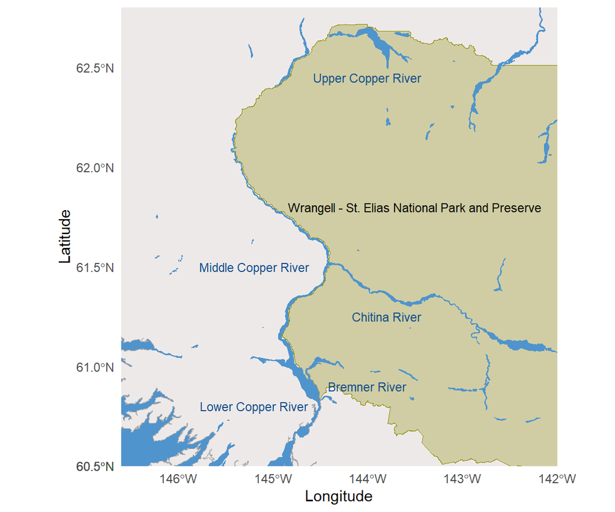

Figure 1. Map of the bald eagles monitoring survey area in the Copper River drainage, Wrangell-St. Elias National Park and Preserve. Major tributaries in the survey area include the Chitina and Bremner rivers.

Two aerial surveys were conducted in 2023 - one to document territorial occupancy, and one to document productivity. Surveys were flown using a small airplane flying at low level (<100m AGL) and low speed (<100 kph), with one experienced observer. Flight paths followed the river’s edge, with the opposite side covered on the return trip. In most cases, the relatively narrow riparian corridor allowed adequate coverage with a single pass on each side of the river. Where the corridor widened, multiple passes were made to adequately evaluate the available habitat.

For all new nests located, the following information was collected:

1. Location (latitude/longitude via handheld Global Positioning System receiver),
2. Count of adult birds,
3. Behavior of adults (incubating, perched),
4. Number of eggs observed,
5. Number of nestlings,
6. Species of nest tree (Populus spp., Picea spp.),
7. Whether the nest tree was alive or dead, and
8. Nest status (good, poor, remnant, gone).

All information except latitude/longitude was recorded on field forms. All nests still intact from the previous year’s surveys were checked for occupancy during the occupancy survey. Information recorded for located nests include:

1. Count of adult birds,
2. Behavior of adults, and
3. Number of eggs or nestlings observed.

During the second survey, all nest locations collected during prior surveys were checked for productivity. Territorial occupancy was defined based on a bird in the nest in incubating posture or two adult birds at a nest or in the nest tree (Postupalsky 1974). For the productivity survey, all nests observed with an incubating bird or two adult birds at a nest during the occupancy survey were checked to determine nest outcome. Multiple passes were commonly needed to count chicks, particularly in the Lower Copper area where cottonwoods are more common, and leaves make counting chicks difficult.

# Results

Table 1. Results summary, 2023 bald eagles survey.

| Metric | Result |
| --- | --- |
| Nests located | 289 |
| Occupied | 103 |
| Successful | 67 |
| Productivity unknown | 6 |
| Young fledged | 101 |
| % nest occupied | 35.6 |
| % nest success | 69.1 |
| Young/occupied nest | 0.98 |

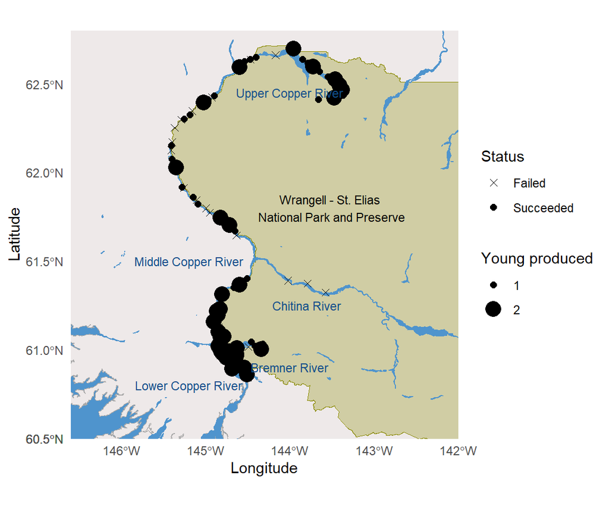

Bald eagle productivity metrics are presented by river segment in Table 2.

Table 2. Bald eagle productivity and success rates by river segment, 2023.

| River segment | Bremner | Chitina | Lower Copper | Middle Copper | Upper Copper |
| --- | --- | --- | --- | --- | --- |
| Nests located | 37 | 23 | 123 | 78 | 28 |
| Occupied | 14 | 4 | 40 | 27 | 18 |
| Successful | 9 | 0 | 27 | 15 | 16 |
| Productivity unknown | 2 | 1 | 3 | 0 | 0 |
| Young fledged | 15 | 0 | 44 | 19 | 23 |
| % nest occupied | 37.84 | 17.39 | 32.52 | 34.62 | 64.29 |
| % nest success | 75 | 0 | 73 | 55.6 | 88.9 |
| Young/occupied nest | 1.07 | 0 | 1.1 | 0.7 | 1.28 |
| Young/successful nest | 1.67 |  | 1.63 | 1.27 | 1.44 |

## Long term trends

Over the 34 year history of the bald eagles monitoring effort in the Copper River study area, there have been 25 surveys (Table 3, Figures 2 and 3). During this time, mean nest occupancy has ranged from 29% to 42%, averaging 36%. Success rates, defined as occupied nests producing young, has ranged from 28% to 69%, averaging 47%. Productivity averaged 1.42 young per successful nest, ranging between 1.18 to 1.63.

The 2016 survey was not finished due to bad weather and has been omitted from the results presented below.

Table 3. Long-term bald eagle productivity metrics, Copper River Valley.

| Year | Nests located | Occupied | Successful | Productivity unknown | Young fledged | % nest occupied | % nest success | Young/occupied nest | Young/successful nest |
| --- | --- | --- | --- | --- | --- | --- | --- | --- | --- |
| 1989 |  | 33 | 18 |  | 27 |  | 55.0 | 0.82 | 1.50 |
| 1990 |  | 70 | 32 |  | 52 |  | 46.0 | 0.74 | 1.63 |
| 1991 |  | 81 | 33 |  | 44 |  | 41.0 | 0.54 | 1.33 |
| 1992 |  | 94 | 47 |  | 71 |  | 50.0 | 0.76 | 1.51 |
| 1993 |  | 93 | 49 |  | 75 |  | 53.0 | 0.81 | 1.53 |
| 1994 |  | 96 | 43 |  | 60 |  | 45.0 | 0.63 | 1.40 |
| 1995 |  | 100 | 49 |  | 67 |  | 49.0 | 0.67 | 1.37 |
| 1996 |  | 100 | 40 |  | 59 |  | 40.0 | 0.59 | 1.48 |
| 2004 | 87 | 25 | 7 | 0 | 10 | 28.7 | 28.0 | 0.40 | 1.43 |
| 2005 | 154 | 57 | 19 | 5 | 29 | 37.0 | 36.5 | 0.51 | 1.53 |
| 2006 | 270 | 103 | 33 | 3 | 43 | 38.1 | 33.0 | 0.42 | 1.30 |
| 2007 | 318 | 111 | 39 | 12 | 53 | 34.9 | 39.4 | 0.48 | 1.36 |
| 2008 | 317 | 93 | 43 | 6 | 66 | 29.3 | 49.4 | 0.71 | 1.53 |
| 2009 | 308 | 130 | 57 | 22 | 80 | 42.2 | 52.8 | 0.62 | 1.40 |
| 2011 | 296 | 102 | 43 | 0 | 59 | 34.5 | 42.2 | 0.58 | 1.37 |
| 2012 | 288 | 109 | 67 | 3 | 98 | 37.8 | 63.2 | 0.90 | 1.46 |
| 2013 | 280 | 105 | 42 | 3 | 54 | 37.5 | 41.2 | 0.51 | 1.29 |
| 2014 | 279 | 101 | 53 | 2 | 74 | 36.2 | 53.5 | 0.73 | 1.40 |
| 2015 | 273 | 110 | 51 | 5 | 66 | 40.3 | 48.6 | 0.60 | 1.29 |
| 2017 | 284 | 106 | 73 | 0 | 116 | 37.3 | 68.9 | 1.09 | 1.59 |
| 2018 | 277 | 103 | 39 | 9 | 46 | 37.2 | 41.5 | 0.45 | 1.18 |
| 2019 | 284 | 84 | 40 | 17 | 53 | 29.6 | 59.7 | 0.63 | 1.32 |
| 2021 | 291 | 105 | 42 | 5 | 58 | 36.1 | 42.0 | 0.55 | 1.38 |
| 2022 | 277 | 111 | 28 | 9 | 36 | 40.1 | 27.5 | 0.32 | 1.29 |
| 2023 | 289 | 103 | 67 | 6 | 101 | 35.6 | 69.1 | 0.98 | 1.51 |

## Success

Long-term bald eagle nest success and productivity metrics at WRST are shown in Figures 2 and 3. Results for the years 1989 through 1996 are from Kozie (1996).

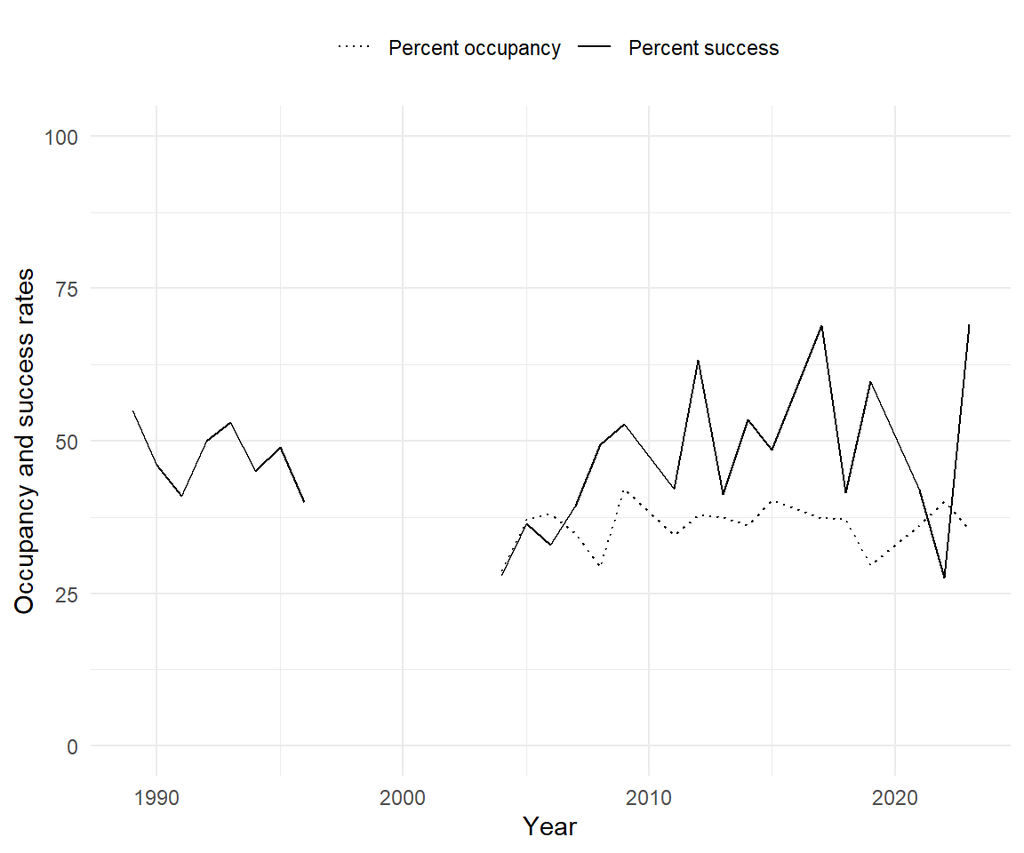

## Productivity

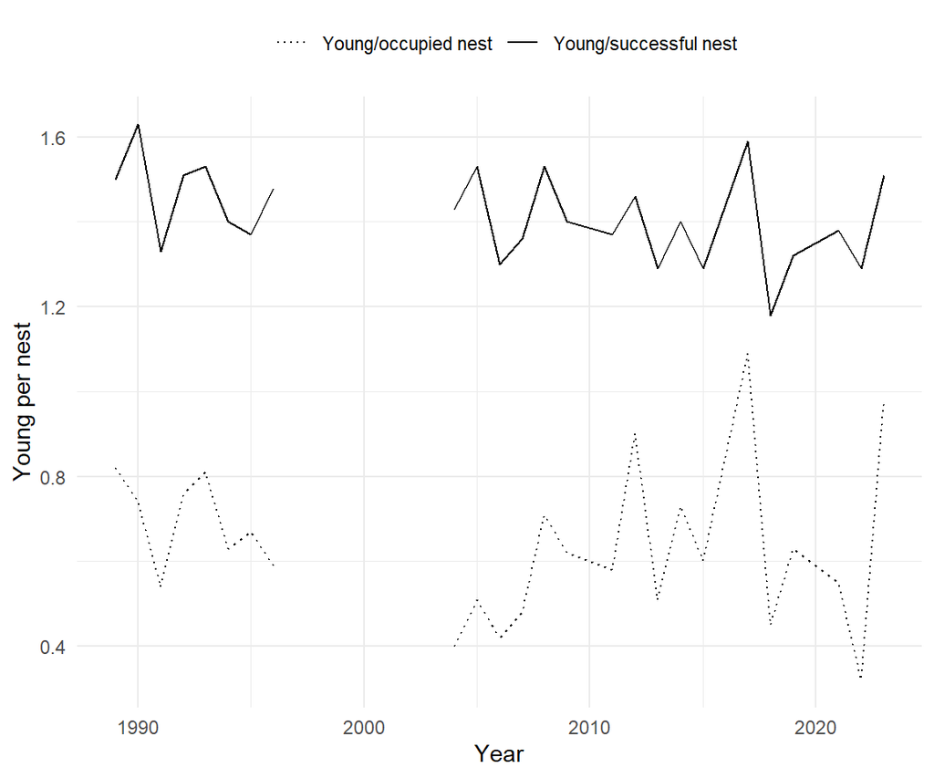

# Discussion

# References

Kozie K. 1996. [Bald Eagle Productivity for Wrangell-St Elias National Park and Preserve 1993-1996](https://irma.nps.gov/DataStore/Reference/Profile/2238328). National Park Service, Wrangell - St. Elias National Park. Unpublished Report. Copper Center, Alaska

Postupalsky, S. 1974. Raptor reproductive success: some problems with methods, criteria, and terminology, IN Raptor Research Report No. 2, Raptor Research Foundation, Vermilion, South Dakota, pp 21-31.

Putera, J. and S.D. Miller. 2018. [Protocol implementation plan for bald eagle monitoring in Wrangell-St. Elias National Park & Preserve, Central Alaska Network: Version 1.0](https://irma.nps.gov/DataStore/Reference/Profile/2256539). Natural Resource Report. NPS/CAKN/NRR—2018/1752. National Park Service. Fort Collins, Colorado.

# Quality Control Checks (Not to be published)

## Survey Attributes from the Surveys Database Table

### Survey details

| DataDirectory | J:_Eagles\2023 |
| --- | --- |
| ReportIRMACode |  |
| ReportURL |  |
| DatasetIRMAReferenceCode |  |

### Abstract

NA

### DataProcessingNotes

NA

### DataQualityNotes

NA

## List of comments

Comments can be useful in troubleshooting strange results

| Nest_ID | Comment | Survey |
| --- | --- | --- |
| 1-5 | Perched, no eggs | Productivity |
| 1-6 | Aspen Tree | Occupancy |
| 108-1 | off river 20 yds | Occupancy |
| 121-5 | POPLAR TREE | Occupancy |
| 122-3 | Deactivate 122-2. 122-3 is POPLAR TREE. | Occupancy |
| 124-2 | new nest, 9501 | Occupancy |
| 146-1 | 2 nests in same tree | Occupancy |
| 150-3 | 9497 new newst w in 150 tern | Occupancy |
| 18-7 | low in tree | Occupancy |
| 182-1 | broken tree | Productivity |
| 190-1 | POPLAR TREE instead of spruce | Occupancy |
| 190-3 | POPLAR TREE | Occupancy |
| 192-4 | MAKE SURE TO DEACTIVATE 192-3 | Occupancy |
| 195-1 | POPLAR TREE instead of spruce | Occupancy |
| 199-1 | low in tree | Occupancy |
| 2-1 | Tree dead | Occupancy |
| 200-3 | 3a | Productivity |
| 208-2 | 3a | Productivity |
| 210-2 | green foliage in nest | Occupancy |
| 210-3 | green foliage in nest | Occupancy |
| 211-3 | 9502 New nest appox location | Occupancy |
| 215-5 | Nest in Poplar Tree | Occupancy |
| 216-2 | green foliage in nest | Occupancy |
| 223-4 | Poplar Tree | Occupancy |
| 224-3 | Poplar Tree | Occupancy |
| 227-2 | 2 eggs present in nest | Occupancy |
| 235-1 | Remove, small nest. | Occupancy |
| 236-5 | 9494 | Productivity |
| 236-5 | new nest | Occupancy |
| 255-2 | Adult 2 behavior not recorded | Occupancy |

[output cut: 52 more lines]

82 rows

## Active nests with DateDiscoveredGone is not NULL

All active nests should have DateDiscoveredGone attributes NULL

| Nest_ID | Date_O | Nest_O | Date_P | StatusCode_P | Comments_O | Comments_P | IsActive | DateDiscoveredGone |
| --- | --- | --- | --- | --- | --- | --- | --- | --- |

0 rows

## Nests With No Productivity Observation

Occasionally observers are unable to re-survey nests for the productivity portion of the survey due to bad weather, smoke, logistical, or other problems. These records should have their StatusCode_P attribute set to ‘NS’ (Not surveyed). The table below shows records with StatusCode_P = ‘NS’

| Nest_ID | RiverSegment | Date_O | OccupancyStatus | ProductivityStatus | Comments_O | Comments_p |
| --- | --- | --- | --- | --- | --- | --- |

0 rows

## Successful Nests With No Recorded Young

The definition of nest success is observed young during the productivity survey. The following records, if any, should be checked.

| Year | Nest_ID | NumYng | StatusCode_P |
| --- | --- | --- | --- |

0 rows

## Chick Age Recorded But No Young Recorded

The following records, if any, have a Chick_Age attribute that is not NULL, but NumYng attribute is NULL or zero. This means a chick stage was recorded, but no chicks were observed.

| Year | Nest_ID | Date_O | Nest_O | Date_P | StatusCode_P | NumYng | Chick_Age | Comments_O | Comments_P | SourceFile | DataProcessingComment |
| --- | --- | --- | --- | --- | --- | --- | --- | --- | --- | --- | --- |

0 rows